[figure not shown]

Autor: **Oleh Zemlianyi**  
Projekt zaliczeniowy z przedmiotu: **Metody Walidacji Modeli Statystycznych**  
Rok: 2025

# Prognozowanie wynagrodzenia w branży Data Science

## 1. Wybór zbioru danych i jego charakterystyka

Do analizy wybrano zbiór danych **„Jobs and Salaries in Data Science”**, dostępny na platformie Kaggle ([link](https://www.kaggle.com/datasets/malingarajapaksha/cleaned)). Zawiera on **5341 rekordów** przedstawiających wynagrodzenia w branży **Data Science i IT** z ostatnich lat.

**Celem analizy** jest predykcja poziomu wynagrodzenia w branży Data Science na podstawie cech dotyczących pracownika i miejsca pracy. W tym celu zmienna ciągła salary_in_usd została przekształcona na zmienną kategoryczną, reprezentującą klasy wynagrodzenia, które stanowią zmienną zależną w zadaniu klasyfikacyjnym. Do przewidywania tej klasy zastosowano różne modele uczenia maszynowego.

### 1.1 Wczytanie danych

Dane zostały zaimportowane z pliku `Cleaned_Dataset.csv` za pomocą funkcji `read.csv()`:

|  | work_year | job_title | job_category | salary_currency | salary | salary_in_usd | employee_residence | experience_level | employment_type | work_setting | company_location | company_size |
| --- | --- | --- | --- | --- | --- | --- | --- | --- | --- | --- | --- | --- |
| 1 | 2023 | Data DevOps Engineer | Data Engineering | EUR | 88000 | 95012 | Germany | Mid-level | Full-time | Hybrid | Germany | L |
| 2 | 2023 | Data Architect | Data Architecture and Modeling | USD | 186000 | 186000 | United States | Senior | Full-time | In-person | United States | M |
| 3 | 2023 | Data Architect | Data Architecture and Modeling | USD | 81800 | 81800 | United States | Senior | Full-time | In-person | United States | M |
| 4 | 2023 | Data Scientist | Data Science and Research | USD | 212000 | 212000 | United States | Senior | Full-time | In-person | United States | M |
| 5 | 2023 | Data Scientist | Data Science and Research | USD | 93300 | 93300 | United States | Senior | Full-time | In-person | United States | M |
| 6 | 2023 | Data Scientist | Data Science and Research | USD | 130000 | 130000 | United States | Senior | Full-time | Remote | United States | M |

### 1.2 Kolumny występujące w zbiorze danych

- `work_year` – Rok, w którym odnotowano wynagrodzenie
- `job_title` – Stanowisko pracy (np. *Data Architect*, *Machine Learning Engineer*)
- `job_category` – Kategoria zawodowa (np. *Data Engineering*, *Data Analysis*)
- `salary_currency` – Waluta, w której podano wynagrodzenie
- `salary` – Wynagrodzenie w oryginalnej walucie
- `salary_in_usd` – Wynagrodzenie przeliczone na dolary amerykańskie
- `employee_residence` – Kraj zamieszkania pracownika
- `experience_level` – Poziom doświadczenia zawodowego (np. *Entry-level*, *Senior*)
- `employment_type` – Rodzaj zatrudnienia (np. *Full-time*, *Part-time*)
- `work_setting` – Tryb pracy (np. *Remote*, *In-person*, *Hybrid*)
- `company_location` – Kraj, w którym znajduje się siedziba firmy
- `company_size` – Wielkość firmy (*S* – mała, *M* – średnia, *L* – duża)

### 1.3 Inżynieria cechy docelowej

Stworzono zmienną **klasyfikacyjną** `salary_range`, na podstawie podziału wartości `salary_in_usd` na trzy kategorie:

- **Niskie wynagrodzenie**: poniżej 75 000 USD
- **Średnie wynagrodzenie**: 75 000–150 000 USD
- **Wysokie wynagrozenie**: powyżej 150 000 USD

```
##
##  niskie średnie wysokie
##     791    2267    2283
```

**Wynik:**  
Po transformacji zmiennej `salary_in_usd` uzyskano nową zmienną `salary_range`, w której:  
- **791** obserwacji należy do klasy “niskie”,  
- **2267** do klasy “średnie”,  
- **2283** do klasy “wysokie”.

Podział ten **nie jest zrównoważony**, co może negatywnie wpływać na skuteczność modeli klasyfikacyjnych, prowadząc do dominacji klas “średnie” oraz “wysokie” nad klasą “niskie”.

## 2. Zdefiniowanie problemu predykcyjnego

Celem niniejszego projektu jest zbudowanie modelu klasyfikacyjnego, który na podstawie cech pracownika oraz firmy będzie przewidywać przynależność do jednej z trzech klas wynagrodzenia (`salary_range`): **niskie**, **średnie** lub **wysokie**.

Problem ma charakter **klasyfikacji wieloklasowej (multiclass classification)**. Zmienna zależna (`salary_range`) została utworzona na podstawie ciągłej zmiennej `salary_in_usd`, poprzez przypisanie przedziałów wartości według ustalonych progów.

Analiza zakłada:

- ograniczenie liczby predyktorów za pomocą metody selekcji cech (Mutual Information, reguła *p/3*);
- zastosowanie modeli o różnych strukturach (logistyczna, drzewa decyzyjne, kNN, SVM, Random Forest);
- ocenę skuteczności modeli za pomocą miar **precision, recall, F1-score** oraz **confusion matrix**.

## 3. Czyszczenie danych i selekcja cech

### 3.1 Sprawdzenie braków danych i duplikatów

Na tym etapie sprawdzono kompletność danych oraz obecność duplikatów.

```r
colSums(is.na(dane))
```

```
##          work_year          job_title       job_category    salary_currency
##                  0                  0                  0                  0
##             salary      salary_in_usd employee_residence   experience_level
##                  0                  0                  0                  0
##    employment_type       work_setting   company_location       company_size
##                  0                  0                  0                  0
##       salary_range
##                  0
```

```r
anyDuplicated(dane)
```

```
## [1] 0
```

Dane nie zawierają brakujących wartości ani zduplikowanych wierszy.

### 3.2 Kodowanie zmiennych

Zmienne employee_residence oraz company_location w oryginalnym zbiorze danych zawierają odpowiednio ponad 60 unikalnych kategorii (krajów). Tak duża liczba kategorii jest problematyczna w kontekście większości modeli predykcyjnych.

Liczba unikalnych krajów zamieszkania pracownika:

```
## [1] 83
```

Liczba unikalnych krajów siedziby firmy:

```
## [1] 70
```

Aby ograniczyć liczbę kategorii w zmiennych krajowych oraz nadać analizie szerszy kontekst, kraje zamieszkania pracownika (employee_residence) oraz siedziby firmy (company_location) zostały zgrupowane według kontynentu (Europa, Ameryka, Azja, Afryka, Oceania).

Dla employee_residence:

```
##
##   Africa Americas     Asia   Europe  Oceania
##       28     4515       66      711       21
```

Dla company_location:

```
##
##   Africa Americas     Asia   Europe  Oceania
##       20     4552       40      705       24
```

Ze względu na bardzo dużą liczbę unikalnych kategorii (ponad 120 stanowisk), zmienna `job_title` okazała się niepraktyczna do wykorzystania w modelach predykcyjnych.W związku z powyższym, zmienna `job_title` nie została uwzględniona w dalszej analizie ani modelowaniu.

### 3.2 Selekcja cech za pomocą Mutual Information

W celu wyboru najbardziej informacyjnych predyktorów względem klasy wynagrodzenia zastosowano metodę selekcji cech opartą na wzajemnej informacji (Mutual Information, MI). W tym celu wszystkie zmienne (z wyjątkiem zmiennej docelowej salary_range oraz oryginalnej wartości wynagrodzenia) zostały zakodowane numerycznie, a następnie obliczono wartości MI względem celu.

```
##                                                  Variable     MI_Score
## employee_residence_continent employee_residence_continent 0.0784854884
## experience_level                         experience_level 0.0743279727
## company_location_continent     company_location_continent 0.0732875072
## job_category                                 job_category 0.0395988696
## company_size                                 company_size 0.0195567875
## work_year                                       work_year 0.0117736969
## employment_type                           employment_type 0.0029576778
## work_setting                                 work_setting 0.0006349244
```

```
## [1] "employee_residence_continent" "experience_level"
## [3] "company_location_continent"
```

### 3.3 Selekcja cech za pomocą Random Forest

Na podstawie miary ważności cech (Mean Decrease Gini) uzyskanej z modelu Random Forest, do dalszej analizy wybrano trzy najbardziej istotne predyktory:

```
## [1] "job_category"                 "experience_level"
## [3] "employee_residence_continent"
```

Do budowy końcowego modelu klasyfikacyjnego wykorzystano zestaw predyktorów wybranych na podstawie ważności cech z modelu Random Forest (`job_category`, `experience_level`, `employee_residence_continent`).

### 3.3 Redukcja zbioru danych do wybranych cech

Finalna ramka danych do budowy modeli:

|  | job_category | experience_level | employee_residence_continent | salary_range |
| --- | --- | --- | --- | --- |
| 1 | Data Engineering | Mid-level | Europe | średnie |
| 2 | Data Architecture and Modeling | Senior | Americas | wysokie |
| 3 | Data Architecture and Modeling | Senior | Americas | średnie |
| 4 | Data Science and Research | Senior | Americas | wysokie |
| 5 | Data Science and Research | Senior | Americas | średnie |
| 6 | Data Science and Research | Senior | Americas | średnie |

**Wniosek:**  
Zredukowany zbiór danych zawiera wyłącznie najważniejsze cechy oraz zmienną celu.  
Zmniejszenie liczby zmiennych pozwala uprościć modele i zwiększyć ich stabilność.

## 4. Eksploracja i wizualizacja zależności

W tej części sprawdzono, jak wybrane predyktory wpływają na klasę wynagrodzenia `salary_range`.  
Wizualizacje mają na celu identyfikację zależności między zmiennymi kategorycznymi a klasą celu.

### 4.1 Rozkład klas `salary_range`

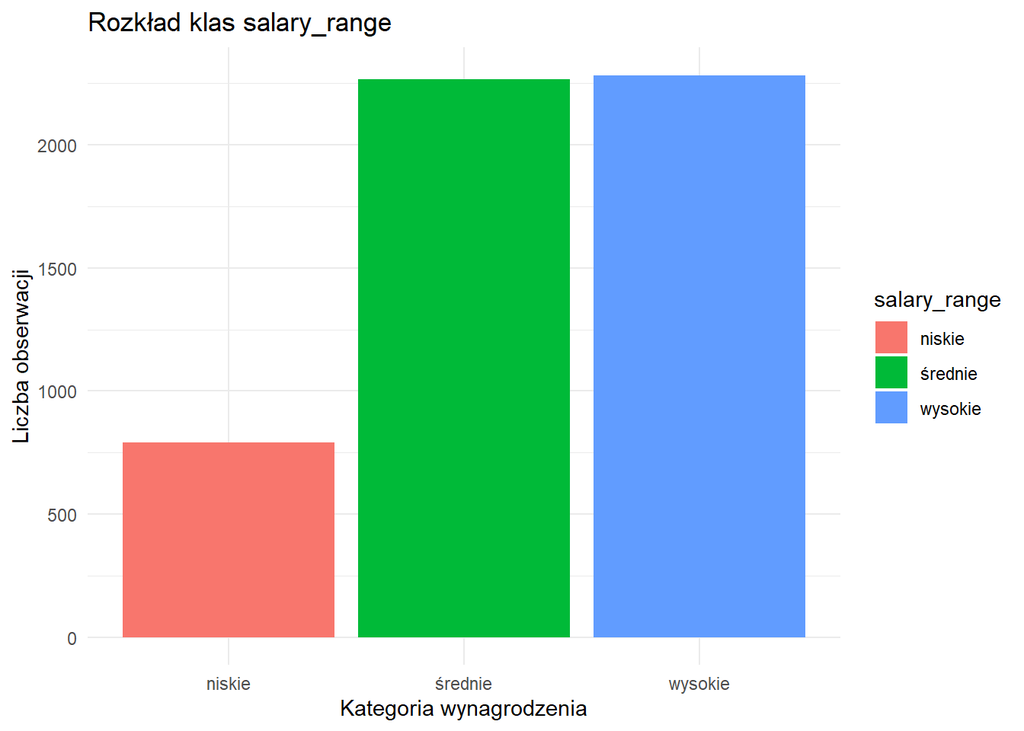

**Wniosek:**  
Zbiory są **wyraźnie niezrównoważone** — klasa **„niskie”** stanowi zdecydowaną mniejszość,  
podczas gdy klasy **„średnie”** i **„wysokie”** występują z podobną częstością i razem dominują w zbiorze.  
Taki rozkład może prowadzić do **niedouczenia modelu względem klasy mniejszościowej**.

### 4.2 Zależność od predyktora 1 – `experience_level`

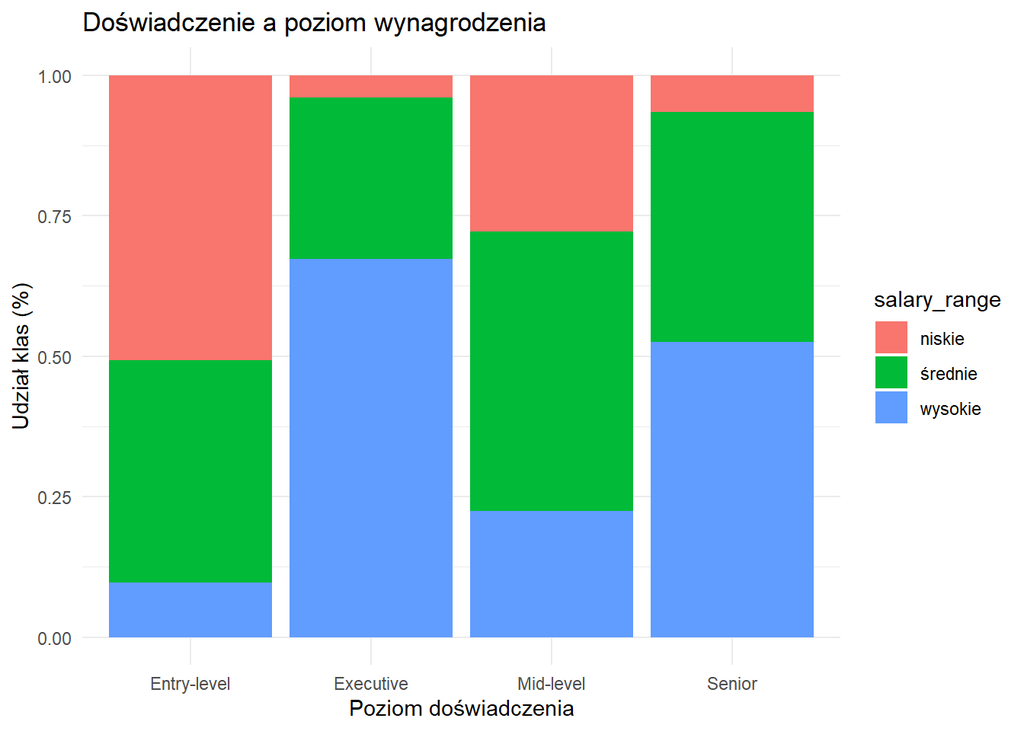

**Wniosek:**  
Im wyższy poziom doświadczenia, tym większe **prawdopodobieństwo przynależności do klasy „wysokie”**.  
Z kolei **najwięcej przypadków klasy „niskie”** występuje w grupie **Entry-level**,  
co jest zgodne z intuicją i potwierdza znaczenie zmiennej `experience_level` w kontekście predykcji wynagrodzenia.

### 4.3 Zależność od predyktora 2 – `employee_residence_continent`

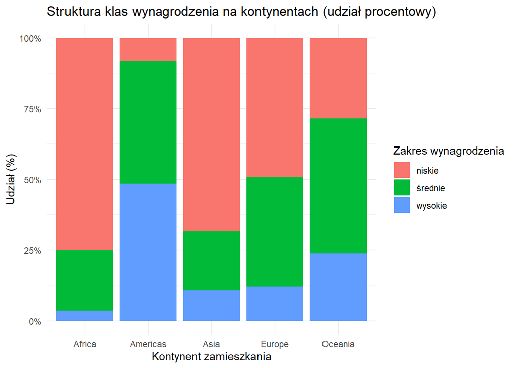

Wyniki te potwierdzają, że poziom wynagrodzenia w branży Data Science istotnie różni się w zależności od kontynentu zamieszkania pracownika

### 4.4 Zależność od predyktora 3 – `job_category`

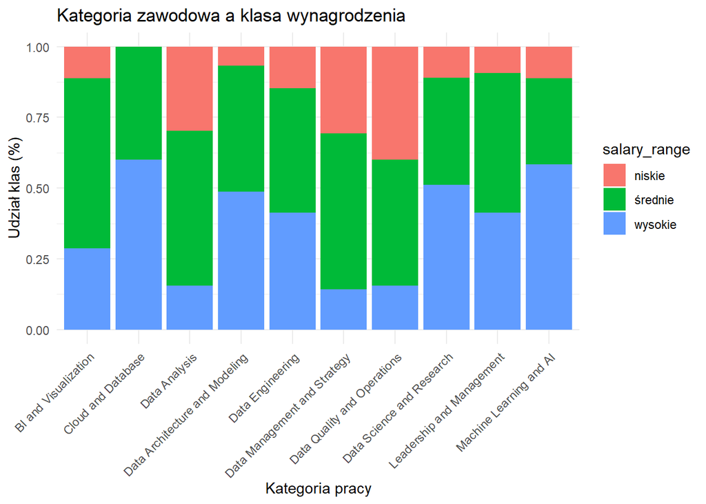

**Kategoria pracy wyraźnie wpływa na poziom wynagrodzenia**, co czyni ją istotnym predyktorem w dalszej analizie.

## 5. Przygotowanie danych do modelowania

### 5.1 Podział zbioru

```r
set.seed(123)
indeksy <- sample(1:nrow(final_data), size = 0.8 * nrow(final_data))
train <- final_data[indeksy, ]
test <- final_data[-indeksy, ]
```

**Wynik:**  
Zbiór treningowy zawiera 4272 obserwacji, testowy 1069.

### 5.2 One-hot encoding zmiennych kategorycznych

W przypadku modeli, które nie obsługują bezpośrednio zmiennych kategorycznych, konieczne jest zastosowanie one-hot encodingu. W analizie zastosowano funkcję dummy_cols() z pakietu fastDummies dla zmiennych `job_category`, `experience_level` oraz `employee_residence_continent`. Przekształcone zostały zarówno dane treningowe, jak i testowe:

```r
library(fastDummies)
train_onehot <- fastDummies::dummy_cols(train,
                                        select_columns = c("job_category", "experience_level", "employee_residence_continent"),
                                        remove_selected_columns = TRUE)
test_onehot <- fastDummies::dummy_cols(test,
                                       select_columns = c("job_category", "experience_level", "employee_residence_continent"),
                                       remove_selected_columns = TRUE)
```

**Wniosek:**  
One-hot encoding zmiennych kategorycznych jest niezbędny wyłącznie dla tych modeli, które nie obsługują faktorów, czyli regresji logistycznej, kNN oraz SVM. W przypadku modeli drzewiastych (rpart, random forest), lepszą praktyką jest pozostawienie zmiennych kategorycznych w formie factor, co zapewnia optymalną wydajność i interpretowalność modelu.

### 5.3 Wyrównanie niezbalansowania klas

Zmienna docelowa salary_range ma wyraźnie **niezrównoważony rozkład klas** w zbiorze trenongowym i wygląda rozkład tak:

```
##
##  niskie średnie wysokie
##     636    1816    1820
```

W celu zrównoważenia liczności klas w zbiorze treningowym zastosowano oversampling — liczność klas mniejszościowych („niskie”, „średnie”) została zwiększona przez losowe powielanie obserwacji, aż do poziomu klasy większościowej („wysokie”). Po oversampling’u rozkład zmiennej `salary_range` jest taki:

```
##
##  niskie średnie wysokie
##    1820    1820    1820
```

## 6. Budowa modeli klasyfikacyjnych

### 6.1 Konfiguracja kontrolna

```r
library(caret)
library(e1071)
library(randomForest)
library(nnet)
library(rpart)
library(class)

set.seed(123)
ctrl <- trainControl(method = "cv", number = 10, classProbs = TRUE)
```

### 6.2 Regresja logistyczna (multinom)

Model regresji logistycznej wieloklasowej (`multinom`) to liniowy model probabilistyczny.  
Jest często stosowany jako bazowa metoda klasyfikacji — szczególnie przy prostych zależnościach między zmiennymi.

```r
library(caret)
library(nnet)

X_train <- train_onehot_balanced %>% select(-salary_range)
y_train <- train_onehot_balanced$salary_range

set.seed(123)
model_log <- train(
  x = X_train,
  y = y_train,
  method = "multinom",
  trControl = ctrl
)

model_log
```

[output not shown]

### 6.3 Drzewo decyzyjne (`rpart`)

Model `rpart` buduje hierarchiczne drzewo reguł decyzyjnych.  
Łatwy do interpretacji, dobrze radzi sobie z danymi kategorycznymi, ale jest podatny na przeuczenie.

```r
library(caret)
library(rpart)

# Oddziel predyktory i zmienną celu
X_train_tree <- train_balanced %>% select(-salary_range)
y_train_tree <- train_balanced$salary_range

set.seed(123)
model_tree <- train(
  x = X_train_tree,
  y = y_train_tree,
  method = "rpart",
  trControl = ctrl
)

model_tree
```

```
## CART
##
## 5460 samples
##    3 predictor
##    3 classes: 'niskie', 'średnie', 'wysokie'
##
## No pre-processing
## Resampling: Cross-Validated (10 fold)
## Summary of sample sizes: 4914, 4914, 4914, 4914, 4914, 4914, ...
## Resampling results across tuning parameters:
##
##   cp          Accuracy   Kappa
##   0.03928571  0.5606227  0.34093407
##   0.09313187  0.5166667  0.27500000
##   0.23873626  0.3912088  0.08681319
##
## Accuracy was used to select the optimal model using the largest value.
## The final value used for the model was cp = 0.03928571.
```

### 6.4 Maszyna wektorów nośnych (SVM)

```r
library(caret)
library(e1071)

set.seed(123)
model_svm <- train(
  x = train_onehot_balanced %>% select(-salary_range),
  y = train_onehot_balanced$salary_range,
  method = "svmRadial",
  trControl = ctrl
)
model_svm
```

```
## Support Vector Machines with Radial Basis Function Kernel
##
## 5460 samples
##   19 predictor
##    3 classes: 'niskie', 'średnie', 'wysokie'
##
## No pre-processing
## Resampling: Cross-Validated (10 fold)
## Summary of sample sizes: 4914, 4914, 4914, 4914, 4914, 4914, ...
## Resampling results across tuning parameters:
##
##   C     Accuracy   Kappa
##   0.25  0.6128205  0.4192308
##   0.50  0.6148352  0.4222527
##   1.00  0.6141026  0.4211538
##
## Tuning parameter 'sigma' was held constant at a value of 0.04902916
## Accuracy was used to select the optimal model using the largest value.
## The final values used for the model were sigma = 0.04902916 and C = 0.5.
```

### 6.5 Random Forest

Random Forest to model oparty na zbiorze losowych drzew decyzyjnych.  
Często zapewnia bardzo dobre wyniki bez konieczności wstępnego dopasowania parametrów.

```r
library(caret)
library(randomForest)

# Oddziel predyktory i zmienną celu
X_train_rf <- train_balanced %>% select(-salary_range)
y_train_rf <- train_balanced$salary_range

set.seed(123)
model_rf <- train(
  x = X_train_rf,
  y = y_train_rf,
  method = "rf",
  trControl = ctrl
)
model_rf
```

```
## Random Forest
##
## 5460 samples
##    3 predictor
##    3 classes: 'niskie', 'średnie', 'wysokie'
##
## No pre-processing
## Resampling: Cross-Validated (10 fold)
## Summary of sample sizes: 4914, 4914, 4914, 4914, 4914, 4914, ...
## Resampling results across tuning parameters:
##
##   mtry  Accuracy   Kappa
##   2     0.6141026  0.4211538
##   3     0.6135531  0.4203297
##
## Accuracy was used to select the optimal model using the largest value.
## The final value used for the model was mtry = 2.
```

**Podsumowanie:**  
Każdy z modeli reprezentuje inny typ podejścia: liniowe, strukturalne, probabilistyczne lub oparte na zbiorach.  
W kolejnym kroku zostaną porównane ich wyniki na zbiorze testowym.

## 7. Ewaluacja modeli

Modele zostały ocenione na zbiorze testowym.  
Porównano je pod względem dokładności predykcji (`accuracy`), czułości (`recall`), precyzji (`precision`) oraz miary F1.

Do oceny wykorzystano pakiet `MLmetrics`.

| Model | Accuracy | Precision | Recall | F1 |
| --- | --- | --- | --- | --- |
| Logistic | 0.5715622 | 0.5510781 | 0.6128075 | 0.5537615 |
| Tree | 0.5781104 | 0.5854370 | 0.5729239 | 0.5349557 |
| SVM | 0.5696913 | 0.5491266 | 0.6113484 | 0.5521545 |
| RF | 0.5706268 | 0.5501713 | 0.6092072 | 0.5528073 |

**Wniosek:**  
Wyniki wszystkich modeli są bardzo zbliżone – różnice w Accuracy, Precision, Recall i F1-score nie przekraczają kilku punktów procentowych. Żaden z modeli nie wykazuje zdecydowanej przewagi – wszystkie uzyskują Accuracy na poziomie około 57–58%.

Najlepsze wyniki (nieznacznie) osiągnął model drzewa decyzyjnego, który może być rekomendowany jako preferowany ze względu na prostotę interpretacji i najwyższą precyzję, jednak różnice są marginalne.

### 7.1 Macierze pomyłek (confusion matrix)

```
## Confusion Matrix and Statistics
##
##           Reference
## Prediction niskie średnie wysokie
##    niskie     119     114      27
##    średnie     21     140      84
##    wysokie     15     197     352
##
## Overall Statistics
##
##                Accuracy : 0.5716
##                  95% CI : (0.5413, 0.6015)
##     No Information Rate : 0.4331
##     P-Value [Acc > NIR] : < 2.2e-16
##
##                   Kappa : 0.3301
##
##  Mcnemar's Test P-Value : < 2.2e-16
##
## Statistics by Class:
##
##                      Class: niskie Class: średnie Class: wysokie
## Sensitivity                 0.7677         0.3104         0.7603
## Specificity                 0.8457         0.8301         0.6502
## Pos Pred Value              0.4577         0.5714         0.6241
## Neg Pred Value              0.9555         0.6226         0.7802
## Prevalence                  0.1450         0.4219         0.4331
## Detection Rate              0.1113         0.1310         0.3293
## Detection Prevalence        0.2432         0.2292         0.5276
## Balanced Accuracy           0.8067         0.5703         0.7052
```

```
## Confusion Matrix and Statistics
##
##           Reference
## Prediction niskie średnie wysokie
##    niskie      88      64      14
##    średnie     29     110      29
##    wysokie     38     277     420
##
## Overall Statistics
##
##                Accuracy : 0.5781
##                  95% CI : (0.5479, 0.6079)
##     No Information Rate : 0.4331
##     P-Value [Acc > NIR] : < 2.2e-16
##
##                   Kappa : 0.3122
##
##  Mcnemar's Test P-Value : < 2.2e-16
##
## Statistics by Class:
##
##                      Class: niskie Class: średnie Class: wysokie
## Sensitivity                0.56774         0.2439         0.9071
## Specificity                0.91466         0.9061         0.4802
## Pos Pred Value             0.53012         0.6548         0.5714
## Neg Pred Value             0.92580         0.6215         0.8713
## Prevalence                 0.14500         0.4219         0.4331
## Detection Rate             0.08232         0.1029         0.3929
## Detection Prevalence       0.15529         0.1572         0.6876
## Balanced Accuracy          0.74120         0.5750         0.6937
```

```
## Confusion Matrix and Statistics
##
##           Reference
## Prediction niskie średnie wysokie
##    niskie     119     114      27
##    średnie     21     139      85
##    wysokie     15     198     351
##
## Overall Statistics
##
##                Accuracy : 0.5697
##                  95% CI : (0.5394, 0.5996)
##     No Information Rate : 0.4331
##     P-Value [Acc > NIR] : < 2.2e-16
##
##                   Kappa : 0.3272
##
##  Mcnemar's Test P-Value : < 2.2e-16
##
## Statistics by Class:
##
##                      Class: niskie Class: średnie Class: wysokie
## Sensitivity                 0.7677         0.3082         0.7581
## Specificity                 0.8457         0.8285         0.6485
## Pos Pred Value              0.4577         0.5673         0.6223
## Neg Pred Value              0.9555         0.6214         0.7782
## Prevalence                  0.1450         0.4219         0.4331
## Detection Rate              0.1113         0.1300         0.3283
## Detection Prevalence        0.2432         0.2292         0.5276
## Balanced Accuracy           0.8067         0.5683         0.7033
```

```
## Confusion Matrix and Statistics
##
##           Reference
## Prediction niskie średnie wysokie
##    niskie     117     110      25
##    średnie     22     139      84
##    wysokie     16     202     354
##
## Overall Statistics
##
##                Accuracy : 0.5706
##                  95% CI : (0.5403, 0.6005)
##     No Information Rate : 0.4331
##     P-Value [Acc > NIR] : < 2.2e-16
##
##                   Kappa : 0.3263
##
##  Mcnemar's Test P-Value : < 2.2e-16
##
## Statistics by Class:
##
##                      Class: niskie Class: średnie Class: wysokie
## Sensitivity                 0.7548         0.3082         0.7646
## Specificity                 0.8523         0.8285         0.6403
## Pos Pred Value              0.4643         0.5673         0.6189
## Neg Pred Value              0.9535         0.6214         0.7807
## Prevalence                  0.1450         0.4219         0.4331
## Detection Rate              0.1094         0.1300         0.3312
## Detection Prevalence        0.2357         0.2292         0.5351
## Balanced Accuracy           0.8036         0.5683         0.7024
```

**Wniosek:**  
Na podstawie wartości F1-score oraz stabilności predykcji, najlepszy wynik uzyskał model:  
Logistic.

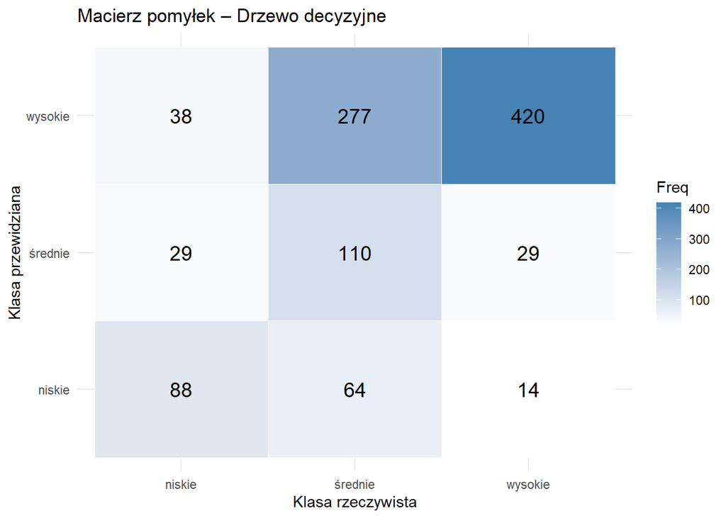

### 7.2 Kalibracja modeli

Kalibracja modeli służy poprawie zgodności predykcji prawdopodobieństwa z rzeczywistym rozkładem klas.

Model regresji logistycznej. Najlepsze hiperparametry:

```
##    alpha     lambda
## 31   0.1 0.01274275
```

```
##                                         Model  Accuracy Precision    Recall
## Accuracy   Regresja logistyczna po kalibracji 0.5715622 0.5510781 0.6128075
## Accuracy1 Regresja logistyczna bez kalibracji 0.5715622 0.5510781 0.6128075
##            F1_Score
## Accuracy  0.5537615
## Accuracy1 0.5537615
```

Kalibracja (strojenie hiperparametrów alpha i lambda) w modelu regresji logistycznej nie wpłynęła na poprawę skuteczności względem modelu bazowego. Obydwa warianty osiągają identyczne wyniki pod względem Accuracy, Precision, Recall oraz F1-score. Oznacza to, że klasyczny model regresji logistycznej jest już odpowiednio dopasowany do danych i nie wymaga dodatkowej regularyzacji ani strojenia.

W przypadku drzewa decyzyjnego przeprowadzono strojenie hiperparametru cp (complexity parameter) metodą siatki (grid search). Wybór optymalnej wartości cp pozwala uzyskać model najlepiej generalizujący, ograniczając ryzyko przeuczenia.

Optymalną wartością hiperparametru złożoności dla drzewa decyzyjnego jest cp = 0.001, przy której model osiąga najwyższą skuteczność predykcyjną na danych walidacyjnych. Oznacza to, że w tym przypadku najlepsze wyniki uzyskujemy, pozwalając modelowi na zbudowanie stosunkowo złożonego drzewa.

```
##      cp
## 1 0.001
```

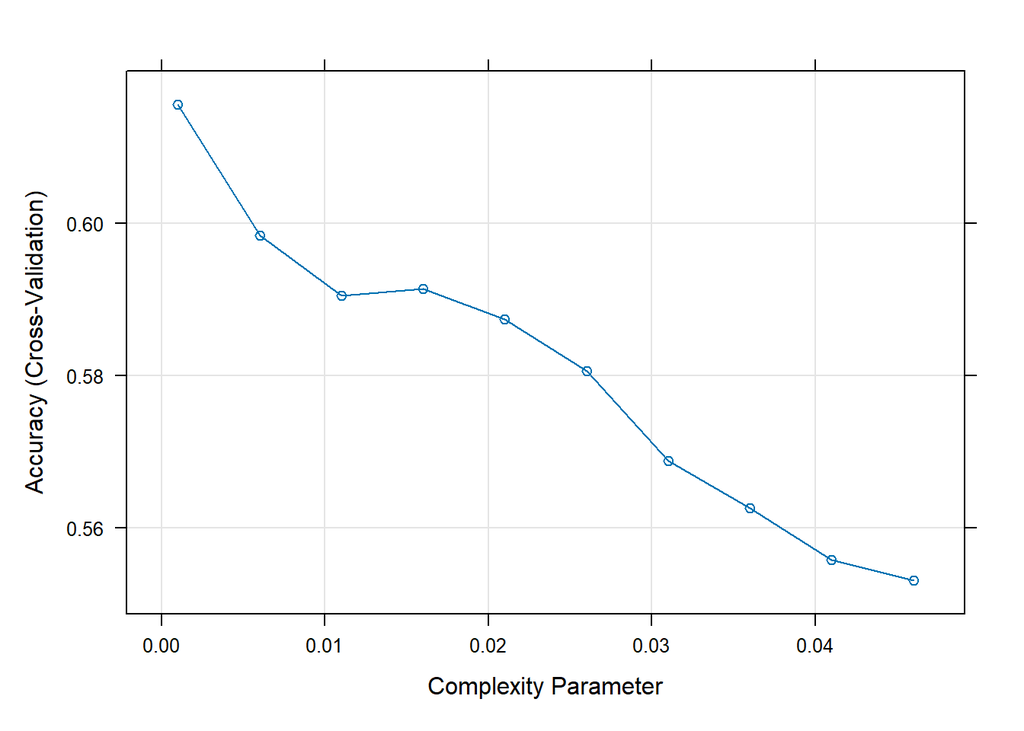

Na powyższym wykresie przedstawiono zależność dokładności modelu drzewa decyzyjnego (Accuracy, Cross-Validation) od wartości hiperparametru złożoności cp (complexity parameter).

- Widzimy, że najwyższą dokładność model osiąga dla najmniejszych wartości cp, w szczególności dla cp = 0.001.
- Wraz ze wzrostem wartości cp, dokładność modelu stopniowo maleje. Oznacza to, że bardziej złożone drzewo (niższy cp) lepiej dopasowuje się do danych.

```
## Confusion Matrix and Statistics
##
##           Reference
## Prediction niskie średnie wysokie
##    niskie      88      64      14
##    średnie     29     110      29
##    wysokie     38     277     420
##
## Overall Statistics
##
##                Accuracy : 0.5781
##                  95% CI : (0.5479, 0.6079)
##     No Information Rate : 0.4331
##     P-Value [Acc > NIR] : < 2.2e-16
##
##                   Kappa : 0.3122
##
##  Mcnemar's Test P-Value : < 2.2e-16
##
## Statistics by Class:
##
##                      Class: niskie Class: średnie Class: wysokie
## Sensitivity                0.56774         0.2439         0.9071
## Specificity                0.91466         0.9061         0.4802
## Pos Pred Value             0.53012         0.6548         0.5714
## Neg Pred Value             0.92580         0.6215         0.8713
## Prevalence                 0.14500         0.4219         0.4331
## Detection Rate             0.08232         0.1029         0.3929
## Detection Prevalence       0.15529         0.1572         0.6876
## Balanced Accuracy          0.74120         0.5750         0.6937
```

```
## Confusion Matrix and Statistics
##
##           Reference
## Prediction niskie średnie wysokie
##    niskie     117     113      26
##    średnie     23     141      86
##    wysokie     15     197     351
##
## Overall Statistics
##
##                Accuracy : 0.5697
##                  95% CI : (0.5394, 0.5996)
##     No Information Rate : 0.4331
##     P-Value [Acc > NIR] : < 2.2e-16
##
##                   Kappa : 0.3261
##
##  Mcnemar's Test P-Value : < 2.2e-16
##
## Statistics by Class:
##
##                      Class: niskie Class: średnie Class: wysokie
## Sensitivity                 0.7548         0.3126         0.7581
## Specificity                 0.8479         0.8236         0.6502
## Pos Pred Value              0.4570         0.5640         0.6234
## Neg Pred Value              0.9533         0.6215         0.7787
## Prevalence                  0.1450         0.4219         0.4331
## Detection Rate              0.1094         0.1319         0.3283
## Detection Prevalence        0.2395         0.2339         0.5267
## Balanced Accuracy           0.8014         0.5681         0.7041
```

```
##                  Model  Accuracy Precision    Recall        F1
## 1        Drzewo bazowe 0.5781104  0.585437 0.5729239 0.5349557
## 2 Drzewo po kalibracji 0.5696913  0.548159 0.6085255 0.5519453
```

- Model bazowy drzewa uzyskał wyższą dokładność (Accuracy = 0.578) oraz wyższą precyzję (Precision = 0.585).
- Model po kalibracji cp charakteryzuje się wyższą czułością (Recall = 0.609) oraz wyższym F1-score (F1 = 0.552).
- Różnice pomiędzy modelami są niewielkie, lecz widoczne — po kalibracji model stał się bardziej „czuły”, kosztem lekkiego spadku precyzji i dokładności.

**Wniosek:**

Model drzewa decyzyjnego po kalibracji hiperparametru cp charakteryzuje się lepszym zbalansowaniem pomiędzy precyzją a czułością (wyższy F1-score), choć nieco niższą ogólną dokładnością.

## 8. Wnioski końcowe

Celem niniejszego projektu było zbudowanie i porównanie modeli klasyfikacyjnych przewidujących przynależność do jednej z trzech klas wynagrodzenia (`salary_range`), na podstawie danych z branży IT/Data Science.

### Wyniki

- Wszystkie analizowane modele osiągnęły porównywalne wyniki skuteczności — dokładność (accuracy) na zbiorze testowym wynosiła ok. 57–58%, bez wyraźnej przewagi jednego algorytmu nad pozostałymi.
- Najwyższą ogólną dokładność oraz precyzję uzyskał model drzewa decyzyjnego przed kalibracją. Jednak po kalibracji drzewa (strojenie cp) wzrosła czułość oraz F1-score, co wskazuje na lepsze zbalansowanie modelu.
- Kalibracja regresji logistycznej nie przyniosła poprawy wyników — zarówno model bazowy, jak i po strojenia hiperparametrów dawały identyczne miary jakości.
- Wybrane cechy predykcyjne – kategoria stanowiska, poziom doświadczenia oraz kontynent zamieszkania pracownika – okazały się wystarczające do uzyskania umiarkowanych wyników predykcyjnych. Inne dostępne zmienne nie podnosiły istotnie jakości klasyfikacji.

### Wnioski ogólne

Przeprowadzona analiza dowodzi, że poziom wynagrodzenia w Data Science można przewidywać z umiarkowaną skutecznością, korzystając z prostych cech opisujących stanowisko, doświadczenie i miejsce pracy. Ostateczny wybór modelu powinien być podyktowany nie tylko skutecznością predykcyjną, lecz także równowagą pomiędzy precyzją a czułością, zależnie od potrzeb biznesowych.